# tarea_1

```r
library(readr)
library(dplyr)
```

```r
library(ggplot2)
library(GGally)
library(purrr)
```

1. Realizar calculos matriciales:

   ```r
   A = matrix( c(7,3,5,1,3,8), nrow=2, ncol=3)
   B = matrix( c(11,12,-7,0,8,9), nrow=2, ncol=3)
   # Matriz transpuesta de A se invierte (i,j) a (j,i)
   t(A)
   ```

   ```
   ##      [,1] [,2]
   ## [1,]    7    3
   ## [2,]    5    1
   ## [3,]    3    8
   ```

   ```r
   # C=A-B se obtiene la matriz con elemento típico
   # (c)_ij = (a)_ij - (b)_ij
   A-B
   ```

   ```
   ##      [,1] [,2] [,3]
   ## [1,]   -4   12   -5
   ## [2,]   -9    1   -1
   ```

   ```r
   # AB no es posible porque ncol(A) != nrow(B)
   #A %*% B

   # A'A es posible (siempre, nrow(A) = nrow(A))
   t(A) %*% A
   ```

   ```
   ##      [,1] [,2] [,3]
   ## [1,]   58   38   45
   ## [2,]   38   26   23
   ## [3,]   45   23   73
   ```

   ```r
   # C=A+B se obtiene la matriz con elemento típico
   # (c)_ij = (a)_ij + (b)_ij
   A+B
   ```

   ```
   ##      [,1] [,2] [,3]
   ## [1,]   18   -2   11
   ## [2,]   15    1   17
   ```

   ```r
   # A'B es posible nrow(A) = nrow(B)
   t(A) %*% B
   ```

   ```
   ##      [,1] [,2] [,3]
   ## [1,]  113  -49   83
   ## [2,]   67  -35   49
   ## [3,]  129  -21   96
   ```

   ```r
   # C = 17.3A se obtiene la matriz con elemento típico
   # (c)_ij = 17.3(a)_ij
   17.3*A
   ```

   ```
   ##       [,1] [,2]  [,3]
   ## [1,] 121.1 86.5  51.9
   ## [2,]  51.9 17.3 138.4
   ```

   ```r
   # (1/19)B análogo al anterior
   (1/19)*B
   ```

   ```
   ##           [,1]       [,2]      [,3]
   ## [1,] 0.5789474 -0.3684211 0.4210526
   ## [2,] 0.6315789  0.0000000 0.4736842
   ```

2. El archivo T01_06.txt en la sección de datos en Piazza contiene datos de un estudio sobre esclerosis múltiple. Dos estímulos visuales diferentes (S1 y S2) producen respuestas en el ojo izquierdo (L) y en el derecho (R) de sujetos, algunos de los cuales tenían esclerosis múltiple (MS).
   - Hacer una gráfica de dispersión de puntos para x2 y x4 para el grupo de multiesclerosis. Comentar sobre la apariencia de la gráfica. Comencemos por leer el dataframe

   ```r
     sclerosis_data <- read_table2('data/T01_06.txt',col_names = FALSE)
     colnames(sclerosis_data) = c('Edad', 'Respuesta_S1', 'Diferencia_S1',
                            'Respuesta_S2', 'Diferencia_S2', 'Grupo')

    knitr::kable(head(sclerosis_data))
   ```

   | Edad | Respuesta_S1 | Diferencia_S1 | Respuesta_S2 | Diferencia_S2 | Grupo |
   | --- | --- | --- | --- | --- | --- |
   | 18 | 152.0 | 1.6 | 198.4 | 0.0 | 0 |
   | 19 | 138.0 | 0.4 | 180.8 | 1.6 | 0 |
   | 20 | 144.0 | 0.0 | 186.4 | 0.8 | 0 |
   | 20 | 143.6 | 3.2 | 194.8 | 0.0 | 0 |
   | 20 | 148.8 | 0.0 | 217.6 | 0.0 | 0 |
   | 21 | 141.6 | 0.8 | 181.6 | 0.8 | 0 |

   Y realizamos la gráfica:

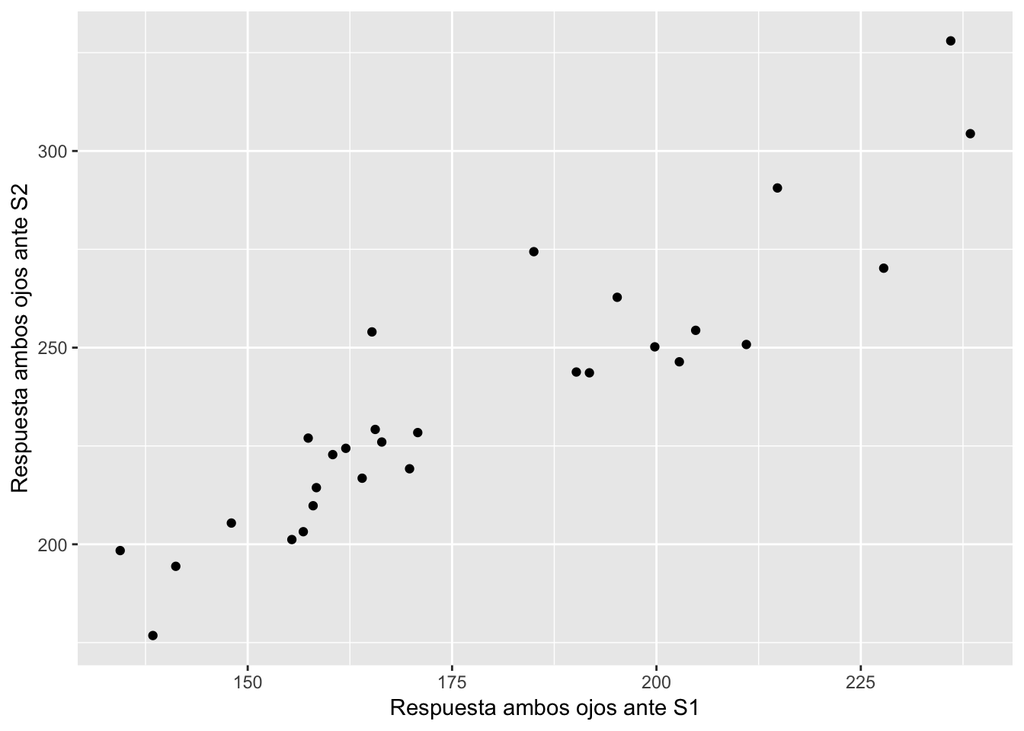

   ```r
       plot_info = filter(sclerosis_data, Grupo == 1) %>%
       select(Respuesta_S1, Respuesta_S2)
       ggplot(plot_info, aes(Respuesta_S1,Respuesta_S2)) +
          geom_point() +
           labs(y="Respuesta ambos ojos ante S2", x="Respuesta ambos ojos ante S1")
   ```

   A primera vista, la gráfica nos permite observar una relación de linealidad entre las variables en cuestión, es decir, la gráfica nos lleva a pensar que la relación entra la respuesta de un paciente a el estímulo 1 está directamente relacionadad (a partir de una relación lineal) con la respuesta a el estímulo 2.
   - Calcular $\overline{x}$, $S$, y $R$ para cada grupo por separado.

   Comencemos por obtener $\overline{x}$:

   ```r
      means = group_by(sclerosis_data, Grupo) %>%
                summarise_all(mean)

     knitr::kable(head(means))
   ```

   | Grupo | Edad | Respuesta_S1 | Diferencia_S1 | Respuesta_S2 | Diferencia_S2 |
   | --- | --- | --- | --- | --- | --- |
   | 0 | 37.98551 | 147.2899 | 1.562319 | 195.6029 | 1.62029 |
   | 1 | 42.06897 | 178.2690 | 12.275862 | 236.9310 | 13.08276 |

   Ahora obtengamos $S$ y $R$:

   ```r
     grupo_0 = filter(sclerosis_data, Grupo==0) %>%
           select(-Grupo)

     grupo_1 = filter(sclerosis_data, Grupo==1) %>%
           select(-Grupo)

     # S
     knitr::kable(cov(grupo_1))
   ```

   |  | Edad | Respuesta_S1 | Diferencia_S1 | Respuesta_S2 | Diferencia_S2 |
   | --- | --- | --- | --- | --- | --- |
   | Edad | 121.13793 | 52.79507 | -20.2197 | 68.13350 | -29.82020 |
   | Respuesta_S1 | 52.79507 | 844.68079 | 244.4632 | 912.41493 | 106.76409 |
   | Diferencia_S1 | -20.21970 | 244.46315 | 317.2640 | 232.36542 | 297.31921 |
   | Respuesta_S2 | 68.13350 | 912.41493 | 232.3654 | 1180.03222 | 81.09734 |
   | Diferencia_S2 | -29.82020 | 106.76409 | 297.3192 | 81.09734 | 351.04719 |

   ```r
     knitr::kable(cov(grupo_0))
   ```

   |  | Edad | Respuesta_S1 | Diferencia_S1 | Respuesta_S2 | Diferencia_S2 |
   | --- | --- | --- | --- | --- | --- |
   | Edad | 277.632140 | 95.398380 | 5.361211 | 103.723572 | 3.241475 |
   | Respuesta_S1 | 95.398380 | 112.294748 | 1.766377 | 106.785030 | 2.042268 |
   | Diferencia_S1 | 5.361211 | 1.766377 | 1.805030 | 2.234817 | 0.501364 |
   | Respuesta_S2 | 103.723572 | 106.785030 | 2.234817 | 185.228815 | 2.351117 |
   | Diferencia_S2 | 3.241475 | 2.042268 | 0.501364 | 2.351117 | 2.355465 |

   ```r
     # R
     knitr::kable(cor(grupo_1))
   ```

   |  | Edad | Respuesta_S1 | Diferencia_S1 | Respuesta_S2 | Diferencia_S2 |
   | --- | --- | --- | --- | --- | --- |
   | Edad | 1.0000000 | 0.1650468 | -0.1031393 | 0.1802078 | -0.1446065 |
   | Respuesta_S1 | 0.1650468 | 1.0000000 | 0.4722334 | 0.9139010 | 0.1960632 |
   | Diferencia_S1 | -0.1031393 | 0.4722334 | 1.0000000 | 0.3797643 | 0.8909017 |
   | Respuesta_S2 | 0.1802078 | 0.9139010 | 0.3797643 | 1.0000000 | 0.1260019 |
   | Diferencia_S2 | -0.1446065 | 0.1960632 | 0.8909017 | 0.1260019 | 1.0000000 |

   ```r
     knitr::kable(cor(grupo_0))
   ```

   |  | Edad | Respuesta_S1 | Diferencia_S1 | Respuesta_S2 | Diferencia_S2 |
   | --- | --- | --- | --- | --- | --- |
   | Edad | 1.0000000 | 0.5402894 | 0.2394891 | 0.4573917 | 0.1267563 |
   | Respuesta_S1 | 0.5402894 | 1.0000000 | 0.1240685 | 0.7404170 | 0.1255725 |
   | Diferencia_S1 | 0.2394891 | 0.1240685 | 1.0000000 | 0.1222209 | 0.2431491 |
   | Respuesta_S2 | 0.4573917 | 0.7404170 | 0.1222209 | 1.0000000 | 0.1125594 |
   | Diferencia_S2 | 0.1267563 | 0.1255725 | 0.2431491 | 0.1125594 | 1.0000000 |

   ```r
     # O bien, para los del grupo 1 obtengamos S y R sin usar las funciones de R:

     #S
     X <- as.matrix(grupo_1)
     n <- nrow(X)
     uno <- rep(1,n)
     H<- diag(n)- uno %*% t(uno)/n
     S <- round(t(X) %*% H %*% X/(n-1),2)
     knitr::kable(data.frame(S))
   ```

   |  | Edad | Respuesta_S1 | Diferencia_S1 | Respuesta_S2 | Diferencia_S2 |
   | --- | --- | --- | --- | --- | --- |
   | Edad | 121.14 | 52.80 | -20.22 | 68.13 | -29.82 |
   | Respuesta_S1 | 52.80 | 844.68 | 244.46 | 912.41 | 106.76 |
   | Diferencia_S1 | -20.22 | 244.46 | 317.26 | 232.37 | 297.32 |
   | Respuesta_S2 | 68.13 | 912.41 | 232.37 | 1180.03 | 81.10 |
   | Diferencia_S2 | -29.82 | 106.76 | 297.32 | 81.10 | 351.05 |

   ```r
     # R
     D <- diag(apply(X,2,var))
     R <- round(solve(D^0.5) %*% S %*% solve(D^0.5),3)
     knitr::kable(data.frame(R))
   ```

   | X1 | X2 | X3 | X4 | X5 |
   | --- | --- | --- | --- | --- |
   | 1.000 | 0.165 | -0.103 | 0.180 | -0.145 |
   | 0.165 | 1.000 | 0.472 | 0.914 | 0.196 |
   | -0.103 | 0.472 | 1.000 | 0.380 | 0.891 |
   | 0.180 | 0.914 | 0.380 | 1.000 | 0.126 |
   | -0.145 | 0.196 | 0.891 | 0.126 | 1.000 |

   - Hacer un scatterplot de todos los datos y comentar sobre las diferencias de cada par de variables en cada uno de los grupos.

   Comencemos por el grupo cero:

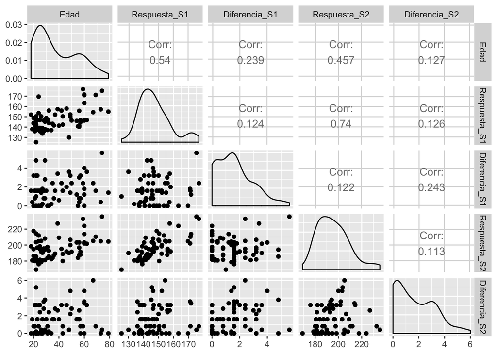

   ```r
   ggpairs(grupo_0)
   ```

   Y con el grupo uno:

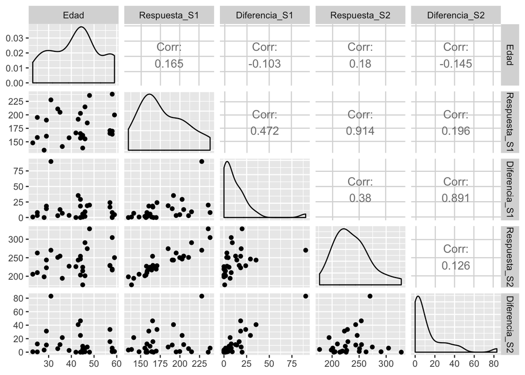

   ```r
   ggpairs(grupo_1)
   ```

   ```r
     data(iris3)
     help(iris3)
   ```

   Ahora obtengamos la matrix $X$ , las medias, la matriz A y Sx

   ```r
   X = filter(iris, Species == 'setosa') %>% select(-Species)

   means = apply(X,2,mean)

   aux = t(apply(X, 1, function(x) x-means)) %>%
         apply(1, function(x) x%*%t(x)) %>%
         data.frame()

   aux = as.list(aux)

   A = aux %>% map(function(x) matrix(x, nrow=4, ncol=4)) %>%
         reduce(`+`)

   Sx <- 1/49*A
   ```

   Ahora los eigenvectores y eigenvalores:

   ```r
   eig = eigen(Sx)
   eig
   ```

   ```
   ## eigen() decomposition
   ## $values
   ## [1] 0.236455690 0.036918732 0.026796399 0.009033261
   ##
   ## $vectors
   ##             [,1]       [,2]       [,3]        [,4]
   ## [1,] -0.66907840 -0.5978840  0.4399628 -0.03607712
   ## [2,] -0.73414783  0.6206734 -0.2746075 -0.01955027
   ## [3,] -0.09654390 -0.4900556 -0.8324495 -0.23990129
   ## [4,] -0.06356359 -0.1309379 -0.1950675  0.96992969
   ```

   ```r
   eigvals = eig$values
   eigvecs = eig$vectors
   ```

   Ahora, mostramos numéricamente las identidades mostradas al ver que la norma de la resta es prácticamente cero

   ```r
     U = as.matrix(eigvecs)
     L = diag(eigvals)
     I = diag(c(1,1,1,1))

     norm(( U %*% L %*% t(U)) - Sx)
   ```

   ```
   ## [1] 8.239937e-17
   ```

   ```r
     norm(U %*% t(U) - I)
   ```

   ```
   ## [1] 1.774622e-15
   ```

   Y haciendo la gráfica:

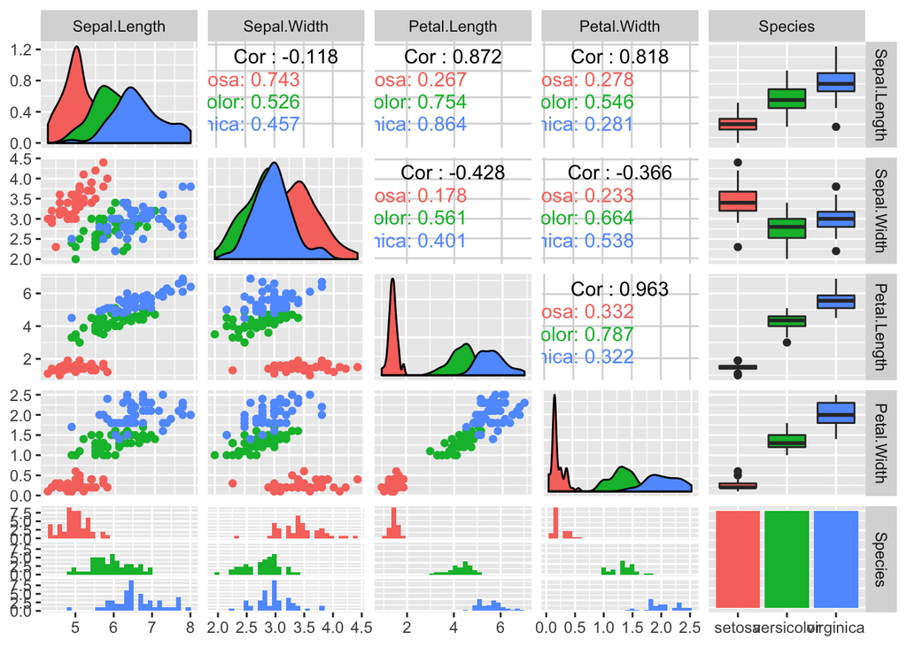

   ```r
       ggpairs(iris, mapping=aes(colour=Species))
   ```

4. Con los datos del ejercicio anterior:
   - Crear una nueva matriz Y de 50 × 5 cuyas primeras cuatro columnas sean las mismas que X y cuya última columna es Petal L. + Petal W. a través de encontrar una matriz C tal que Y = XC.

   La matriz C requerida es la siguiente:

   ```r
       C = matrix( c(1,0,0,0,0,
                     1,0,0,0,0,
                     1,0,0,0,0,
                     1,0,0,1,1), nrow=4, ncol=5)
       C
   ```

   ```
   ##      [,1] [,2] [,3] [,4] [,5]
   ## [1,]    1    0    0    0    0
   ## [2,]    0    1    0    0    0
   ## [3,]    0    0    1    0    1
   ## [4,]    0    0    0    1    1
   ```

   Porque al realizar la multiplicación $XC$ se puede descomponer de la siguiente manera: $XC = Xc_1 + ... Xc_n$, en este caso tenemos que para $1 \leq i \leq 4, c_i = e_i$ con $e_i$ el vector unitario por lo que las primeras 4 columnas de la matriz $XC$ no cambiarán con respecto a las de $X$, asimismo, observamos que $Xc_5 = x_4 + x_4$ de forma que la quinta columnda de la matriz $XC$ tendrá la variable requerida, Petal L. + Petal W.
   - Calcular la matriz de covarianzas muestral SY y sus eigenvalores y eigenvectores. Noten que el eigenvalor más pequeño es 0 (excepto posiblemente por redondeo) y el eigenvector correspondiente consiste de pesos w1, . . . w5 que definen una combinación lineal de columnas de Y que tiene varianza 0. Esto ilustra que los eigenvectores que corresponden a pequeños eigenvalores de SY ayudan a descubrir dependencias lineales entre variables.

   ```r
     X = as.matrix((X))
     Y = X %*% C
     Sy = cov(Y)
     # Obtenemos los valores y vectores propios:

     # Valores propios
     round(eigen(cov(Y))$values,2)
   ```

   ```
   ## [1] 0.24 0.07 0.03 0.01 0.00
   ```

   ```r
     #Vectores propios
     round(eigen(cov(Y))$vectors,2)
   ```

   ```
   ##       [,1]  [,2]  [,3]  [,4]  [,5]
   ## [1,] -0.66  0.04  0.75  0.01  0.00
   ## [2,] -0.71  0.30 -0.64  0.03  0.00
   ## [3,] -0.13 -0.55 -0.09  0.59 -0.58
   ## [4,] -0.08 -0.21 -0.04 -0.79 -0.58
   ## [5,] -0.20 -0.75 -0.13 -0.20  0.58
   ```

   El último valor propio es cero, notamos que si $v=(0,0,-t,-t,t), \ t \in \mathbb{R}$ entonces $v \in Ker(S_y)$

   ```r
      round(Sy%*% matrix( c(0,0,-1,-1,1),ncol = 1),2)
   ```

   ```
   ##      [,1]
   ## [1,]    0
   ## [2,]    0
   ## [3,]    0
   ## [4,]    0
   ## [5,]    0
   ```

   Obteniendo una dependencia lineal entre las variablese $S_y$
   - Mostrar numéricamente que la covarianza muestral $S_Y$ se puede calcular también como $SY = C^{T}S_XC$.

   ```r
     Sy2 = t(C) %*% Sx %*% C

     # Y comparamos
     round(Sy - Sy2, 3)
   ```

   ```
   ##      [,1] [,2] [,3] [,4] [,5]
   ## [1,]    0    0    0    0    0
   ## [2,]    0    0    0    0    0
   ## [3,]    0    0    0    0    0
   ## [4,]    0    0    0    0    0
   ## [5,]    0    0    0    0    0
   ```

  ```r
    Sys.setlocale(category = 'LC_ALL','en_US.UTF-8')
  ```

  ```
  ## [1] "en_US.UTF-8/en_US.UTF-8/en_US.UTF-8/C/en_US.UTF-8/en_US.UTF-8"
  ```

  ```r
    indicadores = read_csv('data/DatosCNBVIndicadores.csv')
    head(indicadores)
  ```

  ```
  ## # A tibble: 6 x 7
  ##   cve_item Concepto       publicacion cve_periodo Textbox3  Monto Flujo_Mes
  ##   <lgl>    <chr>          <chr>             <dbl> <chr>     <dbl> <chr>
  ## 1 NA           Ingresos … ABC Capital      201806 Año en C… 405.  68.42
  ## 2 NA           Ingresos … ABC Capital      201805 Año en C… 337.  71.24
  ## 3 NA           Ingresos … ABC Capital      201804 Año en C… 266.  66.90
  ## 4 NA           Ingresos … Accendo Ba…      201806 Año en C… 156.  33.68
  ## 5 NA           Ingresos … Accendo Ba…      201805 Año en C… 122.  27.09
  ## 6 NA           Ingresos … Accendo Ba…      201804 Año en C…  95.0 24.94
  ```

  - Comenzamos por analizar valores distintos en columnas:

  ```r
    summary(indicadores)
  ```

  ```
  ##  cve_item         Concepto         publicacion         cve_periodo
  ##  Mode:logical   Length:4537        Length:4537        Min.   :201804
  ##  NA's:4537      Class :character   Class :character   1st Qu.:201804
  ##                 Mode  :character   Mode  :character   Median :201805
  ##                                                       Mean   :201805
  ##                                                       3rd Qu.:201806
  ##                                                       Max.   :201806
  ##                                                       NA's   :2269
  ##    Textbox3             Monto           Flujo_Mes
  ##  Length:4537        Min.   :     0.0   Length:4537
  ##  Class :character   1st Qu.:     0.0   Class :character
  ##  Mode  :character   Median :    90.3   Mode  :character
  ##                     Mean   :  3255.6
  ##                     3rd Qu.:   864.5
  ##                     Max.   :426681.7
  ##                     NA's   :590
  ```

  ```r
    table(head(indicadores$publicacion))
  ```

  ```
  ##
  ##   ABC Capital Accendo Banco
  ##             3             3
  ```

  - Al listar los valores distintos en publicación noté que hay uno que no va con ellos, “Textbox4”. Buscamos en qué renglón se encuentra:

  ```r
    indicadores %>%
      add_rownames() %>%
        filter(publicacion == 'Textbox4')
  ```

  ```
  ## # A tibble: 1 x 8
  ##   rowname cve_item Concepto publicacion cve_periodo Textbox3 Monto
  ##   <chr>   <lgl>    <chr>    <chr>             <dbl> <chr>    <dbl>
  ## 1 2269    NA       cve_per… Textbox4             NA Concept…     2
  ## # … with 1 more variable: Flujo_Mes <chr>
  ```

  - Al parecer, a partir de el renglón 2269 hay otra tabla, las leeremos por separado y posteriormente uniremos la información:

  ```r
  indicadores1 = read_csv('data/DatosCNBVIndicadores.csv', n_max = 2268)
  indicadores2 = read_csv('data/DatosCNBVIndicadores.csv', skip = 2270)
  # Renombrando las columnas
  names(indicadores1) <- c("item","concepto","publicacion","periodo","text","monto", 'flujo')
  names(indicadores2) <- c("publicacion","periodo","text","item","concepto","monto", 'flujo')

  indicadores = rbind(indicadores1,indicadores2)
  head(indicadores)
  ```

  ```
  ## # A tibble: 6 x 7
  ##   item  concepto               publicacion   periodo text       monto flujo
  ##   <lgl> <chr>                  <chr>           <dbl> <chr>      <dbl> <chr>
  ## 1 NA        Ingresos por inte… ABC Capital    201806 Año en Cu… 405.  68.42
  ## 2 NA        Ingresos por inte… ABC Capital    201805 Año en Cu… 337.  71.24
  ## 3 NA        Ingresos por inte… ABC Capital    201804 Año en Cu… 266.  66.90
  ## 4 NA        Ingresos por inte… Accendo Banco  201806 Año en Cu… 156.  33.68
  ## 5 NA        Ingresos por inte… Accendo Banco  201805 Año en Cu… 122.  27.09
  ## 6 NA        Ingresos por inte… Accendo Banco  201804 Año en Cu…  95.0 24.94
  ```

  - Haremos un análisis de los valores por columna:

  ```r
  # La priumer columna siempre contiene NA's, no es necesaria
  head(table(indicadores$item))
  ```

  ```
  ## integer(0)
  ```

  ```r
  # La columna concepto contiene variables de tipo categóricas
  head(table(indicadores$concepto))
  ```

  ```
  ##
  ##                         Actividad empresarial o comercial
  ##                                                       378
  ##                                      Créditos Comerciales
  ##                                                       378
  ##                     Por Títulos Conservados a Vencimiento
  ##                                                       378
  ##                     Por Títulos Disponibles para la Venta
  ##                                                       378
  ##                                 Por Títulos para Negociar
  ##                                                       378
  ##         Ingresos provenientes de operaciones de cobertura
  ##                                                       378
  ```

  ```r
  # La columna publicación también contiene variables categóricas
  # y se refieren al banco en cuestión
  head(table(indicadores$publicacion))
  ```

  ```
  ##
  ##      ABC Capital    Accendo Banco         Actinver           Afirme
  ##               72               72               72               72
  ## American Express          Autofin
  ##               72               72
  ```

  ```r
  # La columna de periodo únicamente tiene tres valores,
  # Parece ser que se refiere a 3 meses distintos del año 2018
  # abril (4), mayo (5) y junio (6)
  head(table(indicadores$periodo))
  ```

  ```
  ##
  ## 201804 201805 201806
  ##   1512   1512   1512
  ```

  ```r
  # La columna text únicamente contiene "Año en curso", no es necesaria
  head(table(indicadores$text))
  ```

  ```
  ## Año en Curso
  ##         4536
  ```

  ```r
  # La columna de monto tiene variables de tipo numérico
  summary(indicadores$monto)
  ```

  ```
  ##     Min.  1st Qu.   Median     Mean  3rd Qu.     Max.     NA's
  ##      0.0      0.0     90.3   3256.5    864.4 426681.7      590
  ```

  ```r
  # Finalmente, la columna dee flujo tiene algunos NA y
  # está en tipo categórico pese a ser numérico, convirtiendo.
  indicadores$flujo = as.numeric(indicadores$flujo)
  summary(indicadores$flujo)
  ```

  ```
  ##    Min. 1st Qu.  Median    Mean 3rd Qu.    Max.    NA's
  ##    0.00    0.00    8.04   98.21   95.42  998.88    1010
  ```

  - Finalmente, quitamos las columnas innecesarias:

  ```r
    indicadores = select(indicadores, 'concepto', 'publicacion', 'periodo', 'monto', 'flujo')
  ```

  - Una vez analizadas las variables, lo que representan y el tipo de variable, concluye la fase de limpieza de datos y comienza el análisis exploratorio
  - Surge la pregunta ¿Habrá alguna relación entre las variables monto y flujo? y de ser asi ¿De qué naturaleza esdicha relación? Con las siguientes gráficas se pretende contestar dichas preguntas. Con el resumen estadístico vemos que pese a que el tercer cuantil de los montos es de 864.4 y la media es de 3256.4 el máximo es de 426681.7, parece que tendremos algunos valores extremos, ésto es confirmado con la primer gráfica, al graficar flujos vs montos intentando encontrar una relación veremos que prácticamente todos los puntos se concentran en valores muy chicos.

  ```r
  summary(indicadores$monto)
  ```

  ```
  ##     Min.  1st Qu.   Median     Mean  3rd Qu.     Max.     NA's
  ##      0.0      0.0     90.3   3256.5    864.4 426681.7      590
  ```

  ```r
  summary(indicadores$flujo)
  ```

  ```
  ##    Min. 1st Qu.  Median    Mean 3rd Qu.    Max.    NA's
  ##    0.00    0.00    8.04   98.21   95.42  998.88    1010
  ```

  ```r
  quantile(indicadores$monto, probs = c(.93), na.rm = TRUE)
  ```

  ```
  ##     93%
  ## 7635.14
  ```

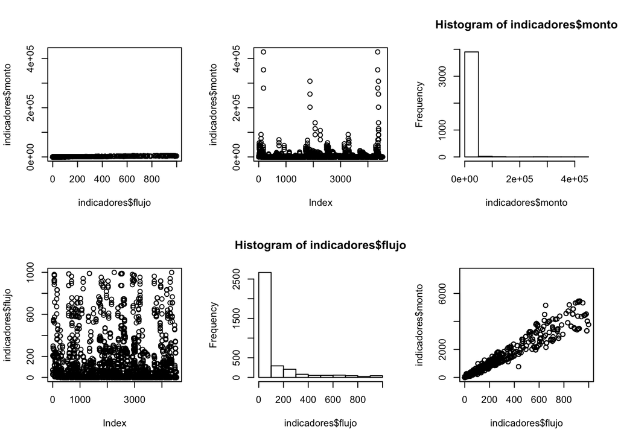

  ```r
  par(mfrow=c(2,3))

  plot(indicadores$flujo, indicadores$monto)

  plot(indicadores$monto)
  hist(indicadores$monto)

  plot(indicadores$flujo)
  hist(indicadores$flujo)

  plot(indicadores$flujo, indicadores$monto, ylim = c(0, 7500))
  ```

  - Surge una nueva pregunta, ¿Dichos valores extremos pertenecen a algún banco o algún concepto en específico? Un primer intento por responder dicha pregunta nos lleva a buscar aquellos bancos y aquellos conceptos en los cuales el monto pertenece al .025 superior de la distribución, tras realizar dicho cálculo, obtenemos que en dichos valores de los 12 conceptos, 6 tienen apariciones, parece ser algo normal, sin embargo, en cuanto a bancos observaremos que de los 63 bancos distintos tan solo 7 tienen apariciones en los datos con valores de monto extremos.

  ```r
    q = quantile(indicadores$monto, probs = c(.975), na.rm = TRUE)
    extremos = filter(indicadores, monto > q)
    table(extremos$concepto)
  ```

  ```
  ##
  ##                                               Actividad empresarial o comercial
  ##                                                                               6
  ##                                                            Créditos Comerciales
  ##                                                                               8
  ##                                                       Por Títulos para Negociar
  ##                                                                               6
  ##                                         Intereses de Cartera de Crédito Vigente
  ##                                                                              34
  ##         Intereses y rendimientos a favor provenientes de inversiones en valores
  ##                                                                               6
  ##                                                          Ingresos por intereses
  ##                                                                              38
  ```

  ```r
    table(extremos$publicacion)
  ```

  ```
  ##
  ##              Banamex  Banamex Consolidado              Banorte
  ##                   12                   12                   12
  ##        BBVA Bancomer                 HSBC            Santander
  ##                   14                    2                   10
  ## Sistema  Consolidado
  ##                   36
  ```

  De la misma manera, realizamos una boxplot y confirmamos que entre ellos hay uno que sobresale drásticamente, ‘Sistema Consolidado’:

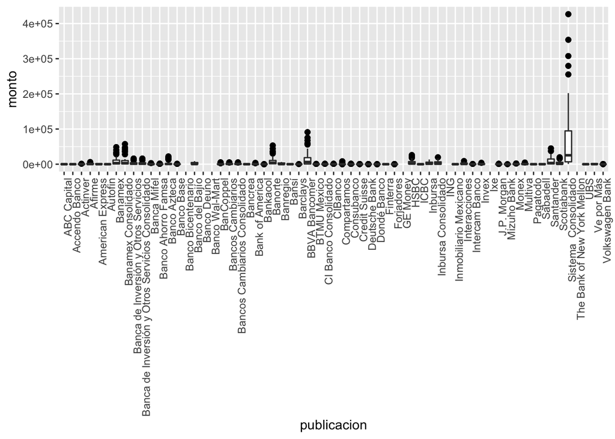

  ```r
    ggplot(indicadores, aes(x=publicacion, y=monto)) +
      geom_boxplot(outlier.colour="black", outlier.shape=16,outlier.size=2, notch=FALSE) +
      theme(axis.text.x = element_text(angle = 90, hjust = 1))
  ```

  - Finalmente, queremos saber cómo afecta el periodo de tiempo en distintos bancos y para distintos conceptos, para esto obtendremos medidas descriptivas de los montos y flujos agrupando por conceptos y periodos en una primera instancia y en bancos y periodos en una segunda

  ```r
    table_1 = group_by(indicadores, concepto, periodo) %>%
          select(monto, flujo) %>%
              summarise(
                    flujo_mean = mean(flujo, na.rm = TRUE),
                    flujo_var = var(flujo, na.rm = TRUE),
                    flujo_max = max(flujo, na.rm = TRUE),
                    monto_mean = mean(monto, na.rm = TRUE),
                    monto_var = var(monto, na.rm = TRUE),
                    monto_max = max(monto, na.rm = TRUE)
              )
  table_2 = group_by(indicadores, publicacion, periodo) %>%
          select(monto, flujo) %>%
              summarise(
                    flujo_mean = mean(flujo, na.rm = TRUE),
                    flujo_var = var(flujo, na.rm = TRUE),
                    flujo_max = max(flujo, na.rm = TRUE),
                    monto_mean = mean(monto, na.rm = TRUE),
                    monto_var = var(monto, na.rm = TRUE),
                    monto_max = max(monto, na.rm = TRUE)
              )
  (head(table_1))
  ```

  ```
  ## # A tibble: 6 x 8
  ## # Groups:   concepto [2]
  ##   concepto periodo flujo_mean flujo_var flujo_max monto_mean monto_var
  ##   <chr>      <dbl>      <dbl>     <dbl>     <dbl>      <dbl>     <dbl>
  ## 1        …  201804       122.    36527.      999.      2835.    9.19e7
  ## 2        …  201805       107.    21133.      714.      3607.    1.49e8
  ## 3        …  201806       106.    21900.      744.      4289.    2.14e8
  ## 4        …  201804       134.    39348.      857.      3728.    1.55e8
  ## 5        …  201805       142.    42637.      870.      4731.    2.50e8
  ## 6        …  201806       140.    44101.      917.      5611.    3.59e8
  ## # … with 1 more variable: monto_max <dbl>
  ```

  ```r
  (head(table_2))
  ```

  ```
  ## # A tibble: 6 x 8
  ## # Groups:   publicacion [2]
  ##   publicacion periodo flujo_mean flujo_var flujo_max monto_mean monto_var
  ##   <chr>         <dbl>      <dbl>     <dbl>     <dbl>      <dbl>     <dbl>
  ## 1 ABC Capital  201804      19.3      778.       66.9       76.2    12190.
  ## 2 ABC Capital  201805      20.4      878.       71.2       96.6    19612.
  ## 3 ABC Capital  201806      20.0      840.       68.4      117.     28569.
  ## 4 Accendo Ba…  201804       7.23      79.7      24.9       28.2     1244.
  ## 5 Accendo Ba…  201805       7.98     100.       27.1       36.2     2051.
  ## 6 Accendo Ba…  201806       9.61     137.       33.7       45.8     3242.
  ## # … with 1 more variable: monto_max <dbl>
  ```